# Replication Analysis: Buy It Now Or Later?

Toshiji Kawagoe, Tomohisa Okada, and Toshihiro Tsuchihashi

2026/09/04

# Data Preparation

This section imports and cleans the experimental and post-experimental questionnaire data used in the analysis.

### Packages

```r
library(tidyverse)
library(stringi)
library(DT)
library(patchwork)
library(texreg)
library(htmltools)
library(bbmle)
library(fixest)
```

### Experimental Data

The raw experimental data are stored in `data/raw/`.

```r
raw_files <- list.files(
  path = "data/raw",
  pattern = "\\.csv$",
  full.names = TRUE
)

original_data <- raw_files %>%

  lapply(function(file) {

    read_csv(
      file,
      col_types = cols(.default = col_character()),
      show_col_types = FALSE
    ) %>%

      select(
        -ends_with("pay_amount2"),
        -ends_with("delta_value"),
        -ends_with("session.config.fix_rounds")
      ) %>%

      rename_with(
        ~ gsub(
          "kto_old1",
          "kto",
          .x
        )
      )

  }) %>%

  bind_rows() %>%

  type_convert(
    na = c("", "NA")
  ) %>%

  # ID variables are always treated as character variables
  mutate(
    participant.label = as.character(participant.label),
    participant.code = as.character(participant.code),
    session.code = as.character(session.code)
  )
```

### Questionnaire Data

The post-experimental questionnaire data are stored in `data/questionnaire/`.

```r
questionnaire_files <- list.files(
  path = "data/questionnaire",
  pattern = "\\.csv$",
  full.names = TRUE
)

q_data <- questionnaire_files %>%

  lapply(function(file) {

    read_csv(
      file,
      col_types = cols(.default = col_character()),
      show_col_types = FALSE
    )

  }) %>%

  bind_rows() %>%

  filter(
    !is.na(participant.label)
  ) %>%

  mutate(
    across(
      c(
        q15,
        q16,
        q17,
        q18,
        q19,
        q20,
        q21,
        q23,
        q24,
        q25
      ),
      ~ stri_trans_general(
        .x,
        "Fullwidth-Halfwidth"
      )
    )
  ) %>%

  mutate(
    across(
      c(
        q15,
        q16,
        q17,
        q18,
        q19,
        q20,
        q21,
        q23,
        q24,
        q25
      ),
      parse_number
    )
  ) %>%

  # Join keys are always treated as character variables
  mutate(
    participant.label = as.character(participant.label),
    session.code = as.character(session.code)
  )
```

### Construction of Questionnaire Variables

The questionnaire is used to construct measures of cognitive reflection, risk preference, and time preference.

```r
q_data <- q_data %>%

  mutate(

    # Cognitive Reflection Test
    crt1 = ifelse(q15 == 25, 1, 0),
    crt2 = ifelse(q16 == 30, 1, 0),
    crt3 = ifelse(q17 == 47, 1, 0),
    crt4 = ifelse(q18 == 5, 1, 0),
    crt5 = ifelse(q19 == 2000, 1, 0),
    crt6 = ifelse(q20 == 5, 1, 0),
    crt7 = ifelse(q21 == 20, 1, 0),
    crt8 = ifelse(q22 == "損失を出している", 1, 0),
    crt9 = ifelse(q23 == 50, 1, 0),
    crt10 = ifelse(q24 == 4, 1, 0),
    crt11 = ifelse(q25 == 29, 1, 0),

    # Time preference
    q14 = ifelse(
      q14 == "1か月後に3000円を受け取る",
      3825,
      parse_number(q14)
    ),

    time_pref =
      1 / (
        1 +
          ((q14 - 3000) / 3000)
      )

  ) %>%

  mutate(

    # Risk preference
    risk_av = case_when(

      q13 == "くじ１：賞金A＝2800円、賞金B＝2800円" ~ 3.46,

      q13 == "くじ２：賞金A＝2400円、賞金B＝3600円" ~ 2.31,

      q13 == "くじ３：賞金A＝2000円、賞金B＝4400円" ~ 0.935,

      q13 == "くじ４：賞金A＝1600円、賞金B＝5200円" ~ 0.605,

      q13 == "くじ５：賞金A＝1200円、賞金B＝6000円" ~ 0.25,

      q13 == "くじ６：賞金A＝200円、賞金B＝7000円" ~ 0

    )

  ) %>%

  mutate(

    crt_mean = rowMeans(
      select(
        .,
        starts_with("crt")
      ),
      na.rm = TRUE
    )

  ) %>%

  select(
    session.code,
    participant.label,
    risk_av,
    time_pref,
    crt_mean,
    crt1,
    crt2,
    crt3,
    crt4,
    crt5,
    crt6,
    crt7,
    crt8,
    crt9,
    crt10,
    crt11
  )
```

### Merge Experimental and Questionnaire Data

Experimental and questionnaire data are matched using session code and participant label.

```r
# Ensure join keys have identical types
original_data <- original_data %>%

  mutate(
    session.code = as.character(session.code),
    participant.label = as.character(participant.label)
  )

q_data <- q_data %>%

  mutate(
    session.code = as.character(session.code),
    participant.label = as.character(participant.label)
  )


# Check that questionnaire observations are unique
q_duplicates <- q_data %>%

  count(
    session.code,
    participant.label
  ) %>%

  filter(
    n > 1
  )

if (nrow(q_duplicates) > 0) {

  print(q_duplicates)

  stop(
    "Duplicate session.code × participant.label observations found in questionnaire data."
  )

}


# Merge questionnaire variables into experimental data
unified_data <- left_join(
  original_data,
  q_data,
  by = c(
    "session.code",
    "participant.label"
  )
)
```

### Construction of Analysis Data

The oTree data are transformed from wide format into a participant-round level dataset.

```r
tidy_data <- unified_data %>%

  # Remove the initial 9 from the participant label
  mutate(
    participant = str_sub(
      participant.label,
      start = 2
    )
  ) %>%

  # Convert oTree session codes into session dates
  mutate(
    session.code = str_replace_all(
      session.code,
      c(
        "qg6y3r9a" = "20230123am",
        "2iop2giw" = "20230124am",
        "okij97gz" = "20230125am",
        "j1lv3s4e" = "20230126am",
        "3in7onqq" = "20230127am",
        "eczksh7i" = "20230127pm",
        "tu4a0x6a" = "20230203pm",
        "mmvdegpf" = "20230519am",
        "kfe3j2be" = "20230519pm",
        "9psjs3mm" = "20230522am",
        "hd8ap5xv" = "20230602am",
        "aa79cz46" = "20230602pm",
        "x8xu57ds" = "20230609am",
        "9kzoh9x9" = "20231004am",
        "0e2ixliv" = "20231006am",
        "5sfv44ze" = "20231006pm",
        "cukcduqr" = "20231013am",
        "c5rlwpru" = "20231013pm",
        "15pwp56x" = "20240614am",
        "ksndt4z8" = "20240617am",
        "ph35usbx" = "20240617pm",
        "qtcxtnhb" = "20240621am",
        "ecx4o6ll" = "20240621pm",
        "5txe5e7n" = "20240624am"
      )
    )
  ) %>%

  select(
    participant,
    participant.label,
    participant.code,
    oTree_id = participant.id_in_session,
    session.code,
    treatment = session.config.treatment,
    total_payoff = participant.payoff,
    risk_av,
    time_pref,
    crt_mean,

    # Select only variables from rounds 1 to 20
    matches(
      "^kto\\.([1-9]|1[0-9]|20)\\."
    )

  ) %>%

  # kto.1.player.xxx -> 1.player.xxx
  rename_with(
    ~ gsub(
      "^kto\\.",
      "",
      .x
    )
  ) %>%

  # 1.player.xxx -> 1__xxx
  rename_with(
    ~ gsub(
      "\\.player\\.",
      "__",
      .x
    )
  ) %>%

  # 1.group.xxx -> 1__xxx
  rename_with(
    ~ gsub(
      "\\.group\\.",
      "__",
      .x
    )
  ) %>%

  # 1.subsession.xxx -> 1__xxx
  rename_with(
    ~ gsub(
      "\\.subsession\\.",
      "__",
      .x
    )
  ) %>%

  pivot_longer(

    cols = -c(
      treatment,
      participant,
      oTree_id,
      session.code,
      total_payoff,
      risk_av,
      time_pref,
      crt_mean,
      participant.label,
      participant.code
    ),

    names_to = c(
      "order",
      ".value"
    ),

    names_sep = "__"

  ) %>%

  # Keep only actual experimental rounds
  filter(
    order %in% as.character(1:20)
  ) %>%

  mutate(

    is_buyout = case_when(
      is_buyout == "0" ~ NA_character_,
      is_buyout == "1" ~ "0",
      is_buyout == "999" ~ "1",
      TRUE ~ as.character(is_buyout)
    )

  ) %>%

  mutate(

    payment_price =
      as.numeric(payment_price) *
      as.numeric(is_winning_bidder),

    payment_price =
      na_if(
        payment_price,
        0
      )

  ) %>%

  mutate(

    order = as.integer(order),

    is_buyout = as.integer(is_buyout),

    num_of_group = as.numeric(num_of_group),

    total_payoff = as.numeric(total_payoff)

  ) %>%

  mutate(

    is_group4 = ifelse(
      num_of_group == 4,
      1,
      0
    )

  ) %>%

  mutate(

    final_payoff = ifelse(
      total_payoff < 0,
      1000,
      total_payoff + 1000
    )

  ) %>%

  select(

    treatment,

    session_delta = delta,

    session = session.code,

    participant,

    case = treatment_id,

    group = id_in_subsession,

    is_group4,

    delta = time_discount_rate,

    pv = private_value,

    discounted_pv = discounted_private_value,

    is_buyout,

    bid_amount,

    payment = payment_price,

    win_buyout = is_winning_buyer,

    win_bid = is_winning_bidder,

    payoff,

    total_payoff,

    final_payoff,

    order,

    risk_av,

    time_pref,

    crt_mean,

    participant.code

  ) %>%

  arrange(
    session,
    participant,
    order
  ) %>%

  as_tibble()


# Safety checks:
# order must contain only rounds 1 to 20
stopifnot(
  !any(is.na(tidy_data$order))
)

stopifnot(
  all(
    tidy_data$order %in% 1:20
  )
)
```

### Sample Restrictions

Bot participants, participants who dropped out during the experiment, and 10 observations with connection failures due to poor network conditions are excluded from the analysis.

```r
tidy_data <- tidy_data %>%

  # Bot participants
  filter(
    !participant %in% c(
      "7777",
      "8888",
      "9999"
    )
  ) %>%

  # Participants who dropped out during the experiment
  filter(
    !(
      session == "20230519pm" &
        participant == "17"
    )
  ) %>%

  filter(
    !(
      session == "20231013pm" &
        participant == "07"
    )
  ) %>%

  filter(!is.na(is_buyout))
#connection failures due to poor network conditions
```

### Save Analysis Data

The cleaned participant-round level dataset is saved in `data/`.

```r
write_csv(
  tidy_data,
  "data/tidy_data.csv"
)
```

# 3.3 Experimental Results

##### P11

- Number of observations

```r
nrow(tidy_data)
```

```
## [1] 9310
```

- Number of participants

```r
tidy_data %>%

  distinct(
    session,
    participant
  ) %>%

  nrow()
```

```
## [1] 466
```

- Mean Experimental Payment

```r
tidy_data %>%

  summarise(
    mean_final_payoff = mean(
      final_payoff,
      na.rm = TRUE
    )
  )
```

| mean_final_payoff |
| --- |
| 2396.559 |

- Analysis Sample

```r
datatable(
  tidy_data,
  extensions = "Scroller",
  options = list(
    deferRender = TRUE,
    scrollY = 200,
    scrollX = TRUE,
    scroller = TRUE
  )
)
```

|  | treatment | session_delta | session | participant | case | group | is_group4 | delta | pv | discounted_pv | is_buyout | bid_amount | payment | win_buyout | win_bid | payoff | total_payoff | final_payoff | order | risk_av | time_pref | crt_mean | participant.code |
| --- | --- | --- | --- | --- | --- | --- | --- | --- | --- | --- | --- | --- | --- | --- | --- | --- | --- | --- | --- | --- | --- | --- | --- |
| 1 | 1 | 0.6 | 20230124am | 01 | 15 | 5 | 1 | 0.6 | 850 | 510 | 1 |  |  | 0 | 0 | 0 | 1226 | 2226 | 1 | 3.46 | 0.7900974453515933 | 1 | lqibugpa |
| 2 | 1 | 0.6 | 20230124am | 01 | 5 | 5 | 1 | 1 | 980 | 980 | 1 |  |  | 1 | 0 | 240 | 1226 | 2226 | 2 | 3.46 | 0.7900974453515933 | 1 | lqibugpa |
| 3 | 1 | 0.6 | 20230124am | 01 | 11 | 5 | 1 | 0.6 | 220 | 132 | 0 |  |  | 0 | 0 | 0 | 1226 | 2226 | 3 | 3.46 | 0.7900974453515933 | 1 | lqibugpa |
| 4 | 1 | 0.6 | 20230124am | 01 | 19 | 9 | 0 | 0.6 | 610 | 366 | 0 | 370 | 60 | 0 | 1 | 306 | 1226 | 2226 | 4 | 3.46 | 0.7900974453515933 | 1 | lqibugpa |
| 5 | 1 | 0.6 | 20230124am | 01 | 20 | 9 | 0 | 0.6 | 500 | 300 | 0 |  |  | 0 | 0 | 0 | 1226 | 2226 | 5 | 3.46 | 0.7900974453515933 | 1 | lqibugpa |
| 6 | 1 | 0.6 | 20230124am | 01 | 4 | 5 | 1 | 1 | 790 | 790 | 1 |  |  | 0 | 0 | 0 | 1226 | 2226 | 6 | 3.46 | 0.7900974453515933 | 1 | lqibugpa |
| 7 | 1 | 0.6 | 20230124am | 01 | 10 | 9 | 0 | 1 | 640 | 640 | 0 | 641 | 160 | 0 | 1 | 480 | 1226 | 2226 | 7 | 3.46 | 0.7900974453515933 | 1 | lqibugpa |
| 8 | 1 | 0.6 | 20230124am | 01 | 14 | 5 | 1 | 0.6 | 770 | 462 | 1 |  |  | 1 | 0 | 30 | 1226 | 2226 | 8 | 3.46 | 0.7900974453515933 | 1 | lqibugpa |
| 9 | 1 | 0.6 | 20230124am | 01 | 8 | 9 | 0 | 1 | 70 | 70 | 0 | 71 |  | 0 | 0 | 0 | 1226 | 2226 | 9 | 3.46 | 0.7900974453515933 | 1 | lqibugpa |
| 10 | 1 | 0.6 | 20230124am | 01 | 9 | 9 | 0 | 1 | 560 | 560 | 0 |  |  | 0 | 0 | 0 | 1226 | 2226 | 10 | 3.46 | 0.7900974453515933 | 1 | lqibugpa |

[output cut: 9300 more lines]

# A. Buyout Decision

##### PP11-12

- **Table 3.** Buyout rates across 𝑵 and 𝜹

```r
tidy_data %>%
  filter(treatment %in% c(1, 2)) %>%
  group_by(delta, is_group4) %>%
  summarise(
    "Buyout Rate" = mean(is_buyout, na.rm = TRUE),
    "SD" = sd(is_buyout, na.rm = TRUE)
  )
```

| delta | is_group4 | Buyout Rate | SD |
| --- | --- | --- | --- |
| 0.2 | 0 | 0.36867470 | 0.4830278 |
| 0.2 | 1 | 0.26328502 | 0.4409486 |
| 0.6 | 0 | 0.20054945 | 0.4009627 |
| 0.6 | 1 | 0.32692308 | 0.4697346 |
| 1.0 | 0 | 0.07060334 | 0.2563257 |
| 1.0 | 1 | 0.31923077 | 0.4664777 |

- Pearson chi-squared tests tests for buyout

```r
# Create readable labels for group size, delta, and buyout
chi_data <- tidy_data %>%
  mutate(
    N = ifelse(is_group4 == 1, "N=4", "N=2"),
    delta_label = paste0("delta=", delta),
    buyout_label = ifelse(is_buyout == 1, "Buyout", "No buyout")
  )

# 1. Chi-squared test: Buyout × N
tab_N <- table(
  Buyout = chi_data$buyout_label,
  N = chi_data$N
)

chisq.test(tab_N)
```

```
##
##  Pearson's Chi-squared test with Yates' continuity correction
##
## data:  tab_N
## X-squared = 208.92, df = 1, p-value < 2.2e-16
```

```r
# 2. Chi-squared test: Buyout × delta
tab_delta <- table(
  Buyout = chi_data$buyout_label,
  Delta = chi_data$delta_label
)

chisq.test(tab_delta)
```

```
##
##  Pearson's Chi-squared test
##
## data:  tab_delta
## X-squared = 78.273, df = 2, p-value < 2.2e-16
```

##### P13

- **Figure 1.** Buyout acceptance rates by net valuation under the rational and Level-k models

```r
tidy_data <- tidy_data %>%

  # ============================================================
  # Experimental condition variables
  # ============================================================
  mutate(
    is_session02 = ifelse(session_delta == 0.2, 1, 0),

    round_delta06 = ifelse(delta == 0.6, 1, 0),
    round_delta02 = ifelse(delta == 0.2, 1, 0),

    ambig_delta = ifelse(treatment %in% c(3, 4), 1, 0),
    ambig_N = ifelse(treatment %in% c(5, 6), 1, 0),

    know_N2 = ifelse(
      is_group4 == 0 & treatment %in% 1:4,
      1, 0
    ),

    know_N4 = ifelse(
      is_group4 == 1 & treatment %in% 1:4,
      1, 0
    ),

    know_delta1 = ifelse(
      delta == 1 & treatment %in% c(1, 2, 5, 6),
      1, 0
    ),

    know_delta_decrease = ifelse(
      delta != 1 & treatment %in% c(1, 2, 5, 6),
      1, 0
    )
  ) %>%

  # ============================================================
  # Thresholds
  # ============================================================
  mutate(

    # Random L1
    th_random = case_when(
      treatment == 1 & is_group4 == 1 & delta == 1   ~ 770,
      treatment == 1 & is_group4 == 1 & delta == 0.6 ~ 760,
      treatment == 1 & is_group4 == 0 & delta == 1   ~ 1000,
      treatment == 1 & is_group4 == 0 & delta == 0.6 ~ 910,

      treatment == 2 & is_group4 == 1 & delta == 1   ~ 770,
      treatment == 2 & is_group4 == 1 & delta == 0.2 ~ 750,
      treatment == 2 & is_group4 == 0 & delta == 1   ~ 1000,
      treatment == 2 & is_group4 == 0 & delta == 0.2 ~ 790,

      treatment == 3 & is_group4 == 1 ~ 760,
      treatment == 3 & is_group4 == 0 ~ 910,

      treatment == 4 & is_group4 == 1 ~ 750,
      treatment == 4 & is_group4 == 0 ~ 790,

      treatment == 5 & delta == 1   ~ 770,
      treatment == 5 & delta == 0.6 ~ 760,

      treatment == 6 & delta == 1   ~ 770,
      treatment == 6 & delta == 0.2 ~ 750,

      TRUE ~ 0
    ),

    # Random L2
    th_random_L2 = case_when(
      treatment == 1 & is_group4 == 1 & delta == 1   ~ 1000,
      treatment == 1 & is_group4 == 1 & delta == 0.6 ~ 850,
      treatment == 1 & is_group4 == 0 & delta == 1   ~ 1000,
      treatment == 1 & is_group4 == 0 & delta == 0.6 ~ 1000,

      treatment == 2 & is_group4 == 1 & delta == 1   ~ 1000,
      treatment == 2 & is_group4 == 1 & delta == 0.2 ~ 770,
      treatment == 2 & is_group4 == 0 & delta == 1   ~ 1000,
      treatment == 2 & is_group4 == 0 & delta == 0.2 ~ 820,

      treatment == 3 & is_group4 == 1 ~ 850,
      treatment == 3 & is_group4 == 0 ~ 1000,

      treatment == 4 & is_group4 == 1 ~ 770,
      treatment == 4 & is_group4 == 0 ~ 820,

      treatment == 5 & delta == 1   ~ 1000,
      treatment == 5 & delta == 0.6 ~ 850,

      treatment == 6 & delta == 1   ~ 1000,
      treatment == 6 & delta == 0.2 ~ 770,

      TRUE ~ 0
    ),

    # Rational
    th_rational = case_when(
      treatment == 1 & is_group4 == 1 & delta == 1   ~ 980,
      treatment == 1 & is_group4 == 1 & delta == 0.6 ~ 840,
      treatment == 1 & is_group4 == 0 & delta == 1   ~ 1000,
      treatment == 1 & is_group4 == 0 & delta == 0.6 ~ 1000,

      treatment == 2 & is_group4 == 1 & delta == 1   ~ 980,
      treatment == 2 & is_group4 == 1 & delta == 0.2 ~ 770,
      treatment == 2 & is_group4 == 0 & delta == 1   ~ 1000,
      treatment == 2 & is_group4 == 0 & delta == 0.2 ~ 820,

      treatment == 3 & is_group4 == 1 ~ 840,
      treatment == 3 & is_group4 == 0 ~ 1000,

      treatment == 4 & is_group4 == 1 ~ 770,
      treatment == 4 & is_group4 == 0 ~ 820,

      treatment == 5 & delta == 1   ~ 980,
      treatment == 5 & delta == 0.6 ~ 840,

      treatment == 6 & delta == 1   ~ 980,
      treatment == 6 & delta == 0.2 ~ 770,

      TRUE ~ 0
    )
  ) %>%

  # ============================================================
  # Variables for theoretical predictions
  # ============================================================
  mutate(
    prob_l0_random = 1 / 2,

    pv_th_random = pv - th_random,
    pv_th_rational = pv - th_rational,

    # Random L1
    is_not_consistent_notbo_random = case_when(
      pv < th_random & is_buyout == 0 ~ 0,
      pv < th_random & is_buyout == 1 ~ 1,
      TRUE ~ NA_real_
    ),

    is_not_consistent_random = case_when(
      pv >= th_random & is_buyout == 0 ~ 1,
      pv < th_random & is_buyout == 1 ~ 1,
      TRUE ~ 0
    ),

    # Rational
    is_not_consistent_notbo_rational = case_when(
      pv < th_rational & is_buyout == 0 ~ 0,
      pv < th_rational & is_buyout == 1 ~ 1,
      TRUE ~ NA_real_
    ),

    is_not_consistent_rational = case_when(
      pv >= th_rational & is_buyout == 0 ~ 1,
      pv < th_rational & is_buyout == 1 ~ 1,
      TRUE ~ 0
    )
  )

bo_pv <- function(x, z, g = NULL, col = 2) {

  # Group data
  if (!is.null(g)) {
    grouping_vars <- rlang::syms(g)
    x <- x %>%
      dplyr::group_by(!!!grouping_vars, {{ z }})
  } else {
    x <- x %>%
      dplyr::group_by({{ z }})
  }

  # Summarize data
  data_summary <- x %>%
    dplyr::summarize(
      total_buyout = sum(is_buyout, na.rm = TRUE),
      count = n(),
      mean_buyout = total_buyout / count,
      .groups = "drop"
    )

  # Create plot
  p <- ggplot(data_summary, aes(x = {{ z }}, y = mean_buyout)) +
    geom_bar(stat = "identity", width = 10) +
    xlab(as.character(substitute(z))) +
    ylab("Buyout Rate") +
    theme_minimal()

  # Add facets if grouping variables are specified
  if (!is.null(g)) {
    facet_formula <- as.formula(
      paste("~", paste(g, collapse = "+"))
    )

    if (is.null(col)) {
      p <- p + facet_wrap(facet_formula)
    } else {
      p <- p + facet_wrap(facet_formula, ncol = col)
    }
  }

  return(p)
}
```

- Left Pane

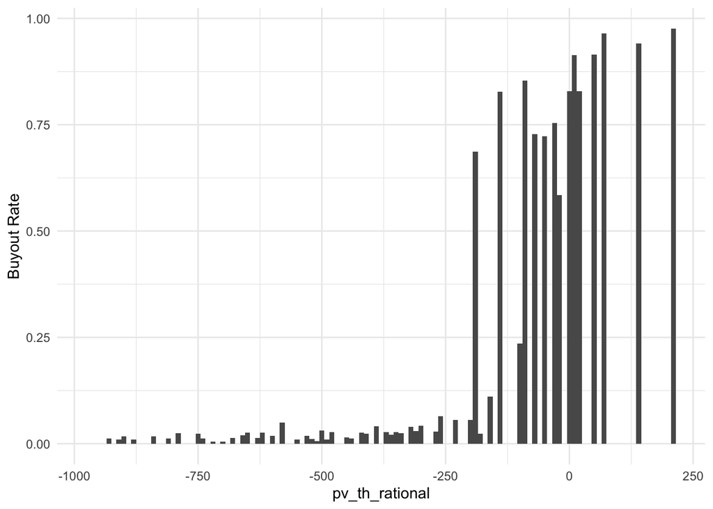

```r
tidy_data %>%
  bo_pv(z = pv_th_rational)
```

- Right Pane

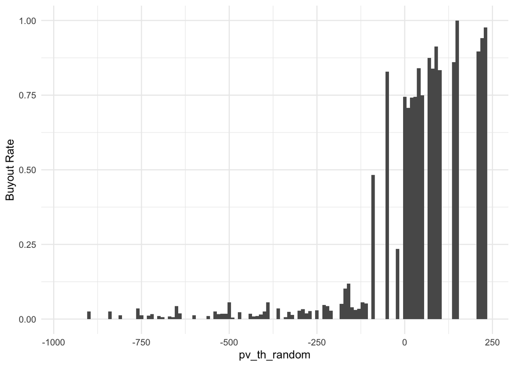

```r
tidy_data %>%
  bo_pv(z = pv_th_random)
```

```r
tidy_data <-
  tidy_data %>%
  mutate(
         is_session06 = ifelse(session_delta == 0.6,1,0),
         is_session02 = ifelse(session_delta == 0.2,1,0),
         round_delta06 = ifelse(delta == 0.6,1,0),
         round_delta02 = ifelse(delta == 0.2,1,0),
         ambig_delta = ifelse(treatment %in% c(3,4),1,0),
         ambig_N = ifelse(treatment %in% c(5,6),1,0),
         pv740 = ifelse(pv >= 740,1,0),
         know_N2 = ifelse(is_group4 == 0 & treatment %in% c(1:4), 1, 0),
         know_N4 = ifelse(is_group4 == 1 & treatment %in% c(1:4), 1, 0),
         know_delta1 = ifelse(delta == 1 & treatment %in% c(1,2,5,6), 1, 0),
         know_delta_decrease = ifelse(delta != 1 & treatment %in% c(1,2,5,6), 1, 0),
         condition_treatment = case_when(
             treatment == 1 ~ "T1",
             treatment == 2 ~ "T2",
             treatment == 3 ~ "T3",
             treatment == 4 ~ "T4",
             treatment == 5 ~ "T5",
             treatment == 6 ~ "T6",
           ),
          condition_detail = case_when(
             treatment == 1 & is_group4 == 1 & delta == 1   ~ "T1_N4_D1",
             treatment == 1 & is_group4 == 1 & delta == 0.6 ~ "T1_N4_D06",
             treatment == 1 & is_group4 == 0 & delta == 1   ~ "T1_N2_D1",
             treatment == 1 & is_group4 == 0 & delta == 0.6 ~ "T1_N2_D06",
             treatment == 2 & is_group4 == 1 & delta == 1   ~ "T2_N4_D1",
             treatment == 2 & is_group4 == 1 & delta == 0.2 ~ "T2_N4_D02",
             treatment == 2 & is_group4 == 0 & delta == 1   ~ "T2_N2_D1",
             treatment == 2 & is_group4 == 0 & delta == 0.2 ~ "T2_N2_D02",
             treatment == 3 & is_group4 == 1  ~ "T3_N4",
             treatment == 3 & is_group4 == 0  ~ "T3_N2",
             treatment == 4 & is_group4 == 1  ~ "T4_N4",
             treatment == 4 & is_group4 == 0  ~ "T4_N2",
             treatment == 5 & delta == 1  ~ "T5_D1",
             treatment == 5 & delta == 0.6  ~ "T5_D06",
             treatment == 6 & delta == 1  ~ "T6_D1",
             treatment == 6 & delta == 0.2  ~ "T6_D02",
             TRUE~ NA_character_
             ),
         th_random =
           case_when(
             treatment == 1 & is_group4 == 1 & delta == 1   ~ 770,
             treatment == 1 & is_group4 == 1 & delta == 0.6 ~ 760,
             treatment == 1 & is_group4 == 0 & delta == 1   ~ 1000,
             treatment == 1 & is_group4 == 0 & delta == 0.6 ~ 910,
             treatment == 2 & is_group4 == 1 & delta == 1   ~ 770,
             treatment == 2 & is_group4 == 1 & delta == 0.2 ~ 750,
             treatment == 2 & is_group4 == 0 & delta == 1   ~ 1000,
             treatment == 2 & is_group4 == 0 & delta == 0.2 ~ 790,
             treatment == 3 & is_group4 == 1  ~ 760,
             treatment == 3 & is_group4 == 0  ~ 910,
             treatment == 4 & is_group4 == 1  ~ 750,
             treatment == 4 & is_group4 == 0  ~ 790,
             treatment == 5 & delta == 1  ~ 770,
             treatment == 5 & delta == 0.6  ~ 760,
             treatment == 6 & delta == 1  ~ 770,
             treatment == 6 & delta == 0.2  ~ 750,
             TRUE~ 0
             ),
         th_random_L2 =
           case_when(
             treatment == 1 & is_group4 == 1 & delta == 1   ~ 1000,
             treatment == 1 & is_group4 == 1 & delta == 0.6 ~ 850,
             treatment == 1 & is_group4 == 0 & delta == 1   ~ 1000,
             treatment == 1 & is_group4 == 0 & delta == 0.6 ~ 1000,
             treatment == 2 & is_group4 == 1 & delta == 1   ~ 1000,
             treatment == 2 & is_group4 == 1 & delta == 0.2 ~ 770,
             treatment == 2 & is_group4 == 0 & delta == 1   ~ 1000,
             treatment == 2 & is_group4 == 0 & delta == 0.2 ~ 820,
             treatment == 3 & is_group4 == 1  ~ 850,
             treatment == 3 & is_group4 == 0  ~ 1000,
             treatment == 4 & is_group4 == 1  ~ 770,
             treatment == 4 & is_group4 == 0  ~ 820,
             treatment == 5 & delta == 1  ~ 1000,
             treatment == 5 & delta == 0.6  ~ 850,
             treatment == 6 & delta == 1  ~ 1000,
             treatment == 6 & delta == 0.2  ~ 770,
             TRUE~ 0
             ),
         th_truthful =
           case_when(
             treatment == 1 & is_group4 == 1 & delta == 1   ~ 1000,
             treatment == 1 & is_group4 == 1 & delta == 0.6 ~ 844.5,
             treatment == 1 & is_group4 == 0 & delta == 1   ~ 1000,
             treatment == 1 & is_group4 == 0 & delta == 0.6 ~ 1000,
             treatment == 2 & is_group4 == 1 & delta == 1   ~ 1000,
             treatment == 2 & is_group4 == 1 & delta == 0.2 ~ 765.3,
             treatment == 2 & is_group4 == 0 & delta == 1   ~ 1000,
             treatment == 2 & is_group4 == 0 & delta == 0.2 ~ 815.8,
             treatment == 3 & is_group4 == 1  ~ 844.5,
             treatment == 3 & is_group4 == 0  ~ 1000,
             treatment == 4 & is_group4 == 1  ~ 765.3,
             treatment == 4 & is_group4 == 0  ~ 815.8,
             treatment == 5 & delta == 1  ~ 1000,
             treatment == 5 & delta == 0.6  ~ 844.5,
             treatment == 6 & delta == 1  ~ 1000,
             treatment == 6 & delta == 0.2  ~ 765.3,
             TRUE~ 0
             ),
         th_rational =
           case_when(
             treatment == 1 & is_group4 == 1 & delta == 1   ~ 980,
             treatment == 1 & is_group4 == 1 & delta == 0.6 ~ 840,
             treatment == 1 & is_group4 == 0 & delta == 1   ~ 1000,
             treatment == 1 & is_group4 == 0 & delta == 0.6 ~ 1000,
             treatment == 2 & is_group4 == 1 & delta == 1   ~ 980,
             treatment == 2 & is_group4 == 1 & delta == 0.2 ~ 770,
             treatment == 2 & is_group4 == 0 & delta == 1   ~ 1000,
             treatment == 2 & is_group4 == 0 & delta == 0.2 ~ 820,
             treatment == 3 & is_group4 == 1  ~ 840,
             treatment == 3 & is_group4 == 0  ~ 1000,
             treatment == 4 & is_group4 == 1  ~ 770,
             treatment == 4 & is_group4 == 0  ~ 820,
             treatment == 5 & delta == 1  ~ 980,
             treatment == 5 & delta == 0.6  ~ 840,
             treatment == 6 & delta == 1  ~ 980,
             treatment == 6 & delta == 0.2  ~ 770,
             TRUE~ 0
             ),
      prob_l0_random = 1/2,
      prob_l0_truthful = pv/1000,
      pv_th_truthful = pv - th_truthful,
      # is_pv_th_truthful_positive = ifelse(pv_th_truthful >= 0, 1, 0),
      # is_pv_th_random_positive = ifelse(pv_th_random >= 0, 1, 0),
      # is_pv_th_rational_positive = ifelse(pv_th_rational >= 0, 1, 0),
      pv_th_random = pv - th_random,
      pv_th_random_L2 = pv - th_random_L2,
      pv_th_rational = pv - th_rational,

      is_consistent_bo_random = ifelse(pv >= th_random & is_buyout == 1, 1,
                              ifelse(pv >= th_random & is_buyout == 0, 0, NA)),

      is_consistent_notbo_random = ifelse(pv < th_random & is_buyout == 0, 1,
                                 ifelse(pv < th_random & is_buyout == 1, 0, NA)),

      is_consistent_random = ifelse(is_consistent_bo_random == 1 | is_consistent_notbo_random == 1, 1, 0) %>%
        replace(is.na(.), 0),
      is_consistent_bo_random_L2 = ifelse(pv >= th_random_L2 & is_buyout == 1, 1,
                              ifelse(pv >= th_random_L2 & is_buyout == 0, 0, NA)),

      is_consistent_notbo_random_L2 = ifelse(pv < th_random_L2 & is_buyout == 0, 1,
                                 ifelse(pv < th_random_L2 & is_buyout == 1, 0, NA)),

      is_consistent_random_L2 = ifelse(is_consistent_bo_random_L2 == 1 | is_consistent_notbo_random_L2 == 1, 1, 0) %>%
        replace(is.na(.), 0),

      is_consistent_bo_truthful = ifelse(pv >= th_truthful & is_buyout == 1, 1,
                                ifelse(pv >= th_truthful & is_buyout == 0, 0, NA)),

      is_consistent_notbo_truthful = ifelse(pv < th_truthful & is_buyout == 0, 1,
                                   ifelse(pv < th_truthful & is_buyout == 1, 0, NA)),

      is_consistent_truthful = ifelse(is_consistent_bo_truthful == 1 | is_consistent_notbo_truthful == 1, 1, 0) %>%
        replace(is.na(.), 0),

      is_consistent_bo_rational= ifelse(pv >= th_rational& is_buyout == 1, 1,
                               ifelse(pv >= th_rational& is_buyout == 0, 0, NA)),

      is_consistent_notbo_rational= ifelse(pv < th_rational& is_buyout == 0, 1,
                                  ifelse(pv < th_rational& is_buyout == 1, 0, NA)),

      is_consistent_rational = ifelse(is_consistent_bo_rational == 1 | is_consistent_notbo_rational == 1, 1, 0) %>%
        replace(is.na(.), 0),

     ) %>%
  mutate(
      is_not_consistent_bo_random = ifelse(pv >= th_random & is_buyout == 1, 0,
                              ifelse(pv >= th_random & is_buyout == 0, 1, NA)),

      is_not_consistent_notbo_random = ifelse(pv < th_random & is_buyout == 0, 0,
                                 ifelse(pv < th_random & is_buyout == 1, 1, NA)),

      is_not_consistent_random = ifelse(is_not_consistent_bo_random == 1 | is_not_consistent_notbo_random == 1, 1, 0) %>%
        replace(is.na(.), 0),
      is_not_consistent_bo_random_L2 = ifelse(pv >= th_random_L2 & is_buyout == 1, 0,
                              ifelse(pv >= th_random_L2 & is_buyout == 0, 1, NA)),

      is_not_consistent_notbo_random_L2 = ifelse(pv < th_random_L2 & is_buyout == 0, 0,
                                 ifelse(pv < th_random_L2 & is_buyout == 1, 1, NA)),

      is_not_consistent_random_L2 = ifelse(is_not_consistent_bo_random_L2 == 1 | is_not_consistent_notbo_random_L2 == 1, 1, 0) %>%
        replace(is.na(.), 0),

      is_not_consistent_bo_rational= ifelse(pv >= th_rational& is_buyout == 1, 0,
                               ifelse(pv >= th_rational& is_buyout == 0, 1, NA)),

      is_not_consistent_notbo_rational= ifelse(pv < th_rational& is_buyout == 0, 0,
                                  ifelse(pv < th_rational& is_buyout == 1, 1, NA)),

      is_not_consistent_rational = ifelse(is_not_consistent_bo_rational == 1 | is_not_consistent_notbo_rational == 1, 1, 0) %>%
        replace(is.na(.), 0),

  ) %>% mutate(count_win_bid = sapply(order, function(o) sum(win_bid[order < o])),
               count_win_bo = sapply(order, function(o) sum(win_buyout[order < o])))
```

- P13
- Under the rational model

```r
tidy_data %>%
  summarise("Over-Acceptance Rate" = mean(is_not_consistent_notbo_rational, na.rm = TRUE),
            "SD" = sd(is_not_consistent_notbo_rational, na.rm = TRUE)
            )
```

| Over-Acceptance Rate | SD |
| --- | --- |
| 0.1256789 | 0.3315081 |

```r
tidy_data %>%
  summarise("Suboptimal Buyout Rate" = mean(is_not_consistent_rational, na.rm = TRUE),
            "SD" = sd(is_not_consistent_rational, na.rm = TRUE)
            )
```

| Suboptimal Buyout Rate | SD |
| --- | --- |
| 0.1276047 | 0.3336671 |

- Under the Random L1 model

```r
tidy_data %>%
  summarise("Over-Acceptance Rate" = mean(is_not_consistent_notbo_random, na.rm = TRUE),
            "SD" = sd(is_not_consistent_notbo_random, na.rm = TRUE)
            )
```

| Over-Acceptance Rate | SD |
| --- | --- |
| 0.03514377 | 0.1841565 |

```r
tidy_data %>%
  summarise("Suboptimal Buyout Rate" = mean(is_not_consistent_random, na.rm = TRUE),
            "SD" = sd(is_not_consistent_random, na.rm = TRUE)
            )
```

| Suboptimal Buyout Rate | SD |
| --- | --- |
| 0.07658432 | 0.265945 |

##### PP13-14

- **Table 4** Buyout rates by ambiguity in 𝑵 and 𝜹
- Left Pane: Buyout Rate by Uncertainty about N

```r
tidy_data %>%
  group_by(ambig_N) %>%
  summarise(
    "Buyout Rate" = mean(is_buyout, na.rm = TRUE),
    "SD" = sd(is_buyout, na.rm = TRUE)
  )
```

| ambig_N | Buyout Rate | SD |
| --- | --- | --- |
| 0 | 0.2339768 | 0.4233903 |
| 1 | 0.2398589 | 0.4270725 |

```r
cross_table <- table(
  tidy_data$is_buyout,
  tidy_data$ambig_N
)

chi_squared_test <- chisq.test(cross_table)

print(chi_squared_test)
```

```
##
##  Pearson's Chi-squared test with Yates' continuity correction
##
## data:  cross_table
## X-squared = 0.34667, df = 1, p-value = 0.556
```

- Right Pane: Buyout Rate by Uncertainty about δ

```r
tidy_data %>%
  group_by(ambig_delta) %>%
  summarise(
    "Buyout Rate" = mean(is_buyout, na.rm = TRUE),
    "SD" = sd(is_buyout, na.rm = TRUE)
  )
```

| ambig_delta | Buyout Rate | SD |
| --- | --- | --- |
| 0 | 0.2416401 | 0.4281132 |
| 1 | 0.2253647 | 0.4178845 |

```r
cross_table <- table(
  tidy_data$is_buyout,
  tidy_data$ambig_delta
)


chi_squared_test <- chisq.test(cross_table)

print(chi_squared_test)
```

```
##
##  Pearson's Chi-squared test with Yates' continuity correction
##
## data:  cross_table
## X-squared = 3.0668, df = 1, p-value = 0.07991
```

# B. Bidding Behavior

##### P15

- **Figure 2** Relationship between bids and valuations

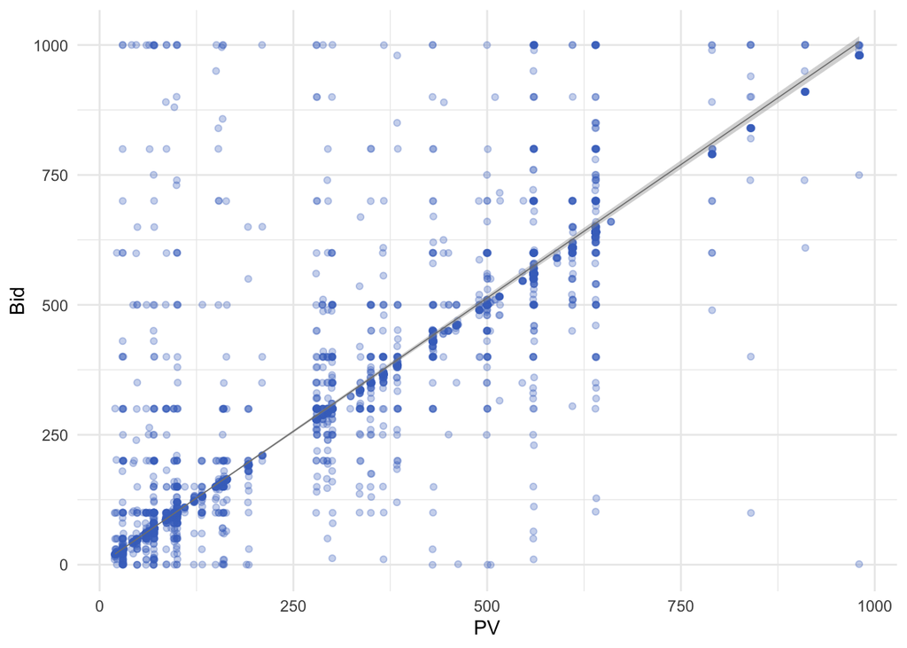

```r
plot_bid <- function(x, g = NULL) {

  # Group data if a grouping variable is specified
  if (!is.null(g)) {
    x <- x %>% group_by({{ g }})
  }

  # Create scatter plot
  p <- ggplot(x) +
    geom_jitter(
      aes(x = discounted_pv, y = bid_amount),
      color = "#4472C4",
      size = 1.4,
      alpha = 0.3,
      show.legend = FALSE
    ) +
    xlab("PV") +
    ylab("Bid") +
    theme_minimal() +
    theme(legend.position = "none")

  # Add linear regression line with the intercept fixed at zero
  p <- p +
    geom_smooth(
      aes(
        x = discounted_pv,
        y = bid_amount,
        color = "#000000"
      ),
      method = "lm",
      formula = y ~ x - 1,
      size = 0.3
    ) +
    scale_color_manual(
      values = c(
        "1" = "#000000",
        "0" = "#000000"
      )
    ) +
    scale_linetype_manual(
      values = c(
        "1" = "solid",
        "0" = "dashed"
      )
    )

  # Add facets if a grouping variable is specified
  if (!is.null(g)) {
    p <- p +
      facet_wrap(
        as.formula(
          paste("~", g)
        )
      )
  }

  return(p)
}


tidy_data %>%
  plot_bid()
```

```r
truth_or_not <- function(x){
    x %>%
    mutate( truth_bid = ifelse(bid_amount == discounted_pv, 1, 0),
          over_bid = ifelse(bid_amount > discounted_pv, 1, 0),
          under_bid = ifelse(bid_amount < discounted_pv, 1, 0),
          bid_status = ifelse(truth_bid ==1, "truth_bid",
                              ifelse(over_bid ==1, "over_bid", "under_bid")))
  }

tidy_data <- truth_or_not(tidy_data)

truth_or_not_table <- function(x) {
  x %>%
    summarise(
      "N" = sum(!is.na(bid_amount)),
      "Truthful (%)" = mean(truth_bid, na.rm = TRUE) * 100,
      "Overbid (%)" = mean(over_bid, na.rm = TRUE) * 100,
      "Underbid (%)" = mean(under_bid, na.rm = TRUE) * 100,
      "SD" = sd(bid_amount - discounted_pv, na.rm = TRUE)
    ) %>%
    round(2)
}


tidy_data %>%
  truth_or_not_table()
```

| N | Truthful (%) | Overbid (%) | Underbid (%) | SD |
| --- | --- | --- | --- | --- |
| 3816 | 55.53 | 25.86 | 18.61 | 125.96 |

##### PP16-17

- **Table 5** Regression results for bidding

```r
# =========================
# Regression analysis of bids
# =========================

bid_reg <- function(x) {

  reg1 <- feols(
    bid_amount ~ discounted_pv + order,
    data = x
  )

  reg2 <- update(
    reg1,
    . ~ . + round_delta06 + round_delta02 + is_group4
  )

  reg3 <- update(
    reg2,
    . ~ . + time_pref + risk_av + crt_mean
  )

  reg4 <- update(
    reg3,
    . ~ . + ambig_delta + ambig_N
  )

  reg5 <- update(
    reg4,
    . ~ . + count_win_bid
  )

  etable(
    list(reg2, reg3, reg4, reg5),
    se = "cluster",
    cluster = "participant.code",
    digits = 2,
    digits.stats = 2,
    depvar = FALSE
  )
}


# Display regression table in HTML
tidy_data %>%
  bid_reg() %>%
  datatable(
    .,
    extensions = "Scroller",
    options = list(
      pageLength = 100,
      ordering = FALSE,
      scrollX = TRUE,
      dom = "t"
    )
  )
```

|  | Var.2 | model 1 | model 2 | model 3 | model 4 |
| --- | --- | --- | --- | --- | --- |
| 1 | Constant | 17.5** (6.1) | 26.7 (58.7) | 28.7 (59.5) | 17.3 (59.2) |
| 2 | discounted_pv | 0.95*** (0.01) | 0.95*** (0.01) | 0.95*** (0.01) | 0.95*** (0.01) |
| 3 | order | 1.7*** (0.38) | 1.7*** (0.39) | 1.8*** (0.39) | 9.4* (4.3) |
| 4 | round_delta06 | -4.4 (5.0) | -4.9 (4.9) | -5.0 (4.9) | -4.1 (4.9) |
| 5 | round_delta02 | 9.4 (6.7) | 10.4 (6.8) | 9.1 (6.8) | 10.2 (6.9) |
| 6 | is_group4 | -6.3 (5.3) | -6.8 (5.3) | -6.1 (5.3) | -5.5 (5.2) |
| 7 | time_pref |  | 45.0 (66.8) | 51.1 (66.4) | 51.9 (66.2) |
| 8 | risk_av |  | -11.9*** (3.1) | -12.2*** (3.1) | -12.2*** (3.1) |
| 9 | crt_mean |  | -44.2** (15.2) | -43.1** (15.1) | -43.2** (15.1) |
| 10 | ambig_delta |  |  | -4.3 (8.4) | -4.6 (8.4) |

[output cut: 7 more lines]

- The regression table is exported as a LaTeX file (`reg_bid.tex`) for use in the manuscript.

```r
reg1 <- feols(
  bid_amount ~ discounted_pv + order,
  data = tidy_data
)

reg2 <- update(
  reg1,
  . ~ . + round_delta06 + round_delta02 + is_group4
)

reg3 <- update(
  reg2,
  . ~ . + time_pref + risk_av + crt_mean
)

reg4 <- update(
  reg3,
  . ~ . + ambig_delta + ambig_N
)

reg5 <- update(
  reg4,
  . ~ . + count_win_bid
)


# Cluster-robust standard errors by participant
se_reg2 <- se(
  reg2,
  cluster = ~ participant.code
)

se_reg3 <- se(
  reg3,
  cluster = ~ participant.code
)

se_reg4 <- se(
  reg4,
  cluster = ~ participant.code
)

se_reg5 <- se(
  reg5,
  cluster = ~ participant.code
)


# Cluster-robust p-values
p_reg2 <- pvalue(
  reg2,
  cluster = ~ participant.code
)

p_reg3 <- pvalue(
  reg3,
  cluster = ~ participant.code
)

p_reg4 <- pvalue(
  reg4,
  cluster = ~ participant.code
)

p_reg5 <- pvalue(
  reg5,
  cluster = ~ participant.code
)


reg_tex <- texreg(
  list(
    reg2,
    reg3,
    reg4,
    reg5
  ),
  override.se = list(
    se_reg2,
    se_reg3,
    se_reg4,
    se_reg5
  ),
  override.pvalues = list(
    p_reg2,
    p_reg3,
    p_reg4,
    p_reg5
  ),
  caption.above = TRUE,
  caption = "Regression Results",
  stars = c(0.01, 0.05, 0.1),
  dcolumn = TRUE,
  custom.model.names = c(
    "Model 1",
    "Model 2",
    "Model 3",
    "Model 4"
  ),
  booktabs = TRUE,
  use.packages = FALSE
)

# Export the table to a LaTeX file
cat(
  reg_tex,
  file = "reg_bid.tex"
)
```

# Appendix D

```r
# =========================
# Logit regression analysis of buyout decisions
# =========================

# Model 1
reg_logit1 <- glm(
  is_buyout ~
    know_N2 +
    know_N4 +
    know_delta1 +
    know_delta_decrease +
    know_delta_decrease:is_session02 +
    pv +
    order,
  data = tidy_data,
  family = binomial
)

# Model 2: Add individual characteristics
reg_logit2 <- update(
  reg_logit1,
  ~ . + risk_av + time_pref + crt_mean
)

# Model 3: Add previous buyout experience
reg_logit3 <- update(
  reg_logit2,
  ~ . + count_win_bo
)


# =========================
# Cluster-robust standard errors at the participant level
# =========================

vcov_logit1 <- sandwich::vcovCL(
  reg_logit1,
  cluster = ~ participant.code
)

vcov_logit2 <- sandwich::vcovCL(
  reg_logit2,
  cluster = ~ participant.code
)

vcov_logit3 <- sandwich::vcovCL(
  reg_logit3,
  cluster = ~ participant.code
)


se_logit1 <- sqrt(diag(vcov_logit1))
se_logit2 <- sqrt(diag(vcov_logit2))
se_logit3 <- sqrt(diag(vcov_logit3))


z_logit1 <- coef(reg_logit1) / se_logit1
z_logit2 <- coef(reg_logit2) / se_logit2
z_logit3 <- coef(reg_logit3) / se_logit3


p_logit1 <- 2 * pnorm(abs(z_logit1), lower.tail = FALSE)
p_logit2 <- 2 * pnorm(abs(z_logit2), lower.tail = FALSE)
p_logit3 <- 2 * pnorm(abs(z_logit3), lower.tail = FALSE)


# =========================
# Display regression table in HTML
# =========================

reg_logit_html <- htmlreg(
  list(
    reg_logit1,
    reg_logit2,
    reg_logit3
  ),
  override.se = list(
    se_logit1,
    se_logit2,
    se_logit3
  ),
  override.pvalues = list(
    p_logit1,
    p_logit2,
    p_logit3
  ),
  caption.above = TRUE,
  caption = "Logit Regression Results",
  stars = c(0.01, 0.05, 0.1),
  custom.model.names = c(
    "Model 1",
    "Model 2",
    "Model 3"
  ),
  custom.note = "Cluster-robust standard errors at the participant level in parentheses."
)

cat(
  reg_logit_html,
  file = "reg_logit.html"
)

includeHTML(
  "reg_logit.html"
)
```

Logit Regression Results

|  | Model 1 | Model 2 | Model 3 |
| --- | --- | --- | --- |
| (Intercept) | -9.72*** | -9.84*** | -9.88*** |
|  | (0.59) | (1.19) | (1.18) |
| know_N2 | -0.27* | -0.29* | -0.29* |
|  | (0.16) | (0.16) | (0.16) |
| know_N4 | 0.34** | 0.33** | 0.33** |
|  | (0.15) | (0.15) | (0.15) |
| know_delta1 | -0.38** | -0.34** | -0.34** |
|  | (0.16) | (0.16) | (0.16) |
| know_delta_decrease | 0.21 | 0.24 | 0.24 |
|  | (0.17) | (0.17) | (0.17) |
| pv | 0.01*** | 0.01*** | 0.01*** |
|  | (0.00) | (0.00) | (0.00) |
| order | -0.03*** | -0.03*** | 0.02 |
|  | (0.01) | (0.01) | (0.15) |
| know_delta_decrease:is_session02 | 0.85*** | 0.87*** | 0.88*** |
|  | (0.17) | (0.17) | (0.17) |
| risk_av |  | 0.13*** | 0.13*** |
|  |  | (0.05) | (0.05) |
| time_pref |  | 0.33 | 0.33 |
|  |  | (1.15) | (1.15) |
| crt_mean |  | -1.06*** | -1.06*** |
|  |  | (0.21) | (0.21) |
| count_win_bo |  |  | -0.00 |
|  |  |  | (0.00) |
| AIC | 4084.87 | 4020.02 | 4021.95 |
| BIC | 4141.98 | 4098.55 | 4107.62 |
| Log Likelihood | -2034.43 | -1999.01 | -1998.98 |
| Deviance | 4068.87 | 3998.02 | 3997.95 |
| Num. obs. | 9310 | 9310 | 9310 |

Cluster-robust standard errors at the participant level in parentheses.

- The regression table is also exported as a LaTeX file (`reg_logit.tex`) for use in the manuscript.

```r
reg_logit_tex <- texreg(
  list(
    reg_logit1,
    reg_logit2,
    reg_logit3
  ),
  override.se = list(
    se_logit1,
    se_logit2,
    se_logit3
  ),
  override.pvalues = list(
    p_logit1,
    p_logit2,
    p_logit3
  ),
  caption.above = TRUE,
  caption = "Logit Regression Results",
  stars = c(0.01, 0.05, 0.1),
  dcolumn = TRUE,
  custom.model.names = c(
    "Model 1",
    "Model 2",
    "Model 3"
  ),
  custom.note = "Cluster-robust standard errors at the participant level in parentheses.",
  booktabs = TRUE,
  use.packages = FALSE
)

cat(
  reg_logit_tex,
  file = "reg_logit.tex"
)
```

# Appendix E

- For verification purposes, the estimation is run for 50 trials.
- The best-fitting result from 1,000,000 trials is reported below.

```r
# =========================
# Maximum likelihood estimation
# =========================

trial_num <- 50

mls <- function(p, q, c, d) {

  # Choice probabilities for L1 and L2
  para_l1 <- c * (pv - th_random)
  prob_l1 <- 1 / (1 + exp(-para_l1))

  para_l2 <- d * (pv - th_random_L2)
  prob_l2 <- 1 / (1 + exp(-para_l2))

  # Population shares of L1 and L2
  rate_l1 <- 1 / (1 + exp(-p))
  rate_l2 <- 1 / (1 + exp(-q))

  # Mixture probability
  prob <- (1 - rate_l1 - rate_l2) * prob_l0_random +
    rate_l1 * prob_l1 +
    rate_l2 * prob_l2

  # Log-likelihood
  log_lik <- is_buyout * log(prob) +
    (1 - is_buyout) * log(1 - prob)

  log_lik_sum <- sum(log_lik)

  return(-log_lik_sum)
}


# List to store estimation results
results <- list()


# Repeat estimation with different random starting values
for (i in 1:trial_num) {

  # Generate random starting values
  start_values <- list(
    p = rnorm(1, 0, 50),
    q = rnorm(1, 0, 50),
    c = rnorm(1, 0, 50),
    d = rnorm(1, 0, 50)
  )

  # Run maximum likelihood estimation while catching errors
  res <- tryCatch({
    mle2(
      mls,
      start = start_values,
      data = tidy_data
    )
  }, error = function(e) {
    return(NULL)
  })

  # Store results only if estimation succeeds
  if (!is.null(res)) {

    log_lik_value <- logLik(res)

    results[[length(results) + 1]] <- list(
      start_values = start_values,
      res = res,
      log_lik = log_lik_value
    )
  }
}


# Check whether any estimation attempt succeeded
if (length(results) == 0) {

  print("Estimation failed in all trials.")

} else {

  # Select the trial with the highest log-likelihood
  best_result <- results[[
    which.max(
      sapply(results, function(x) x$log_lik)
    )
  ]]

  print("Results from the trial with the highest log-likelihood:")
  print(best_result$start_values)
  print(summary(best_result$res))

  # Report estimated population shares of L0, L1, and L2
  print(
    paste(
      "L0 share:",
      1 -
        1 / (1 + exp(-coef(best_result$res)["p"])) -
        1 / (1 + exp(-coef(best_result$res)["q"])),

      "L1 share:",
      1 / (1 + exp(-coef(best_result$res)["p"])),

      "L2 share:",
      1 / (1 + exp(-coef(best_result$res)["q"]))
    )
  )
}
```

```
## [1] "Results from the trial with the highest log-likelihood:"
## $p
## [1] 0.8201747
##
## $q
## [1] -44.7754
##
## $c
## [1] 57.78277
##
## $d
## [1] 68.44977
##
## Maximum likelihood estimation
##
## Call:
## mle2(minuslogl = mls, start = start_values, data = tidy_data)
##
## Coefficients:
##    Estimate Std. Error z value     Pr(z)
## p   1.84219    0.04531  40.658 < 2.2e-16 ***
## q -44.77540    0.00000    -Inf < 2.2e-16 ***
## c  57.78277    0.00000     Inf < 2.2e-16 ***
## d  68.44977    0.00000     Inf < 2.2e-16 ***
## ---
## Signif. codes:  0 '***' 0.001 '**' 0.01 '*' 0.05 '.' 0.1 ' ' 1
##
## -2 log L: 5005.408
## [1] "L0 share: 0.136792457460235 L1 share: 0.863207542539765 L2 share: 3.5833774430798e-20"
```

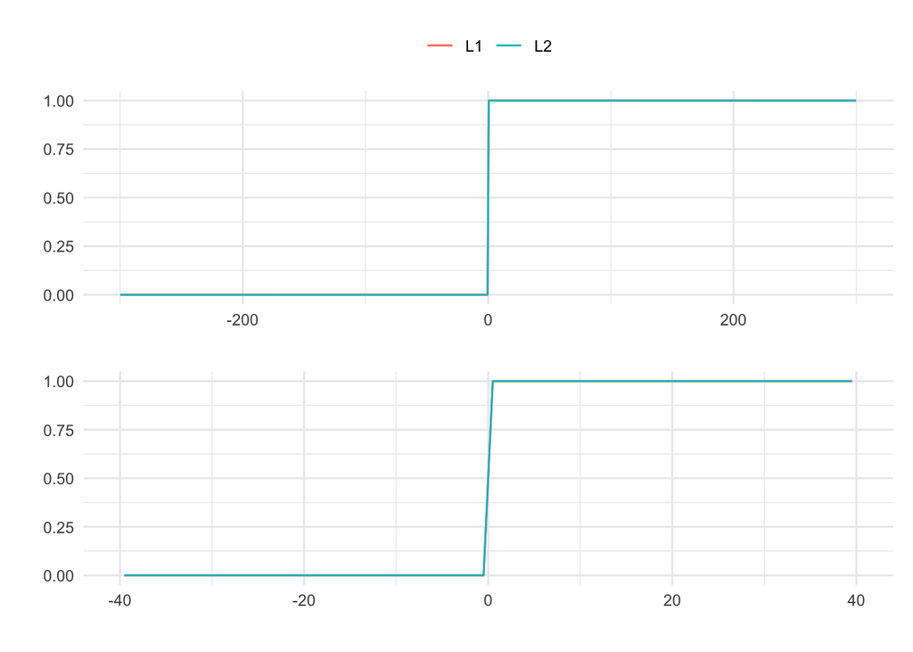

```
## c: 57.78277 d: 68.44977
```

```r
# =========================
# Plot sigmoid functions for L1 and L2
# =========================

sigmoid_fig <- function(c, d) {

  # Set the range of x
  x <- seq(
    -500,
    500,
    length.out = 1000
  )

  # Calculate sigmoid functions for L1 and L2
  sigmoid_L1 <- 1 / (1 + exp(-(c * x)))
  sigmoid_L2 <- 1 / (1 + exp(-(d * x)))

  # Create data frame for plotting
  sigmoid_data <- data.frame(
    x = x,
    sigmoid_L1 = sigmoid_L1,
    sigmoid_L2 = sigmoid_L2
  )

  # Create the plot
  p <- ggplot(
    sigmoid_data,
    aes(x = x)
  ) +
    geom_line(
      aes(
        y = sigmoid_L1,
        color = "L1"
      )
    ) +
    geom_line(
      aes(
        y = sigmoid_L2,
        color = "L2"
      )
    ) +
    labs(
      x = "",
      y = ""
    ) +
    theme_minimal()

  # Full-range plot
  p1 <- p +
    scale_x_continuous(
      limits = c(-300, 300)
    ) +
    theme(
      legend.position = "top",
      legend.title = element_blank()
    )

  # Zoomed-in plot
  p2 <- p +
    scale_x_continuous(
      limits = c(-40, 40)
    ) +
    theme(
      legend.position = "none"
    )

  print(p1 / p2)

  cat(
    "c:", c,
    "d:", d,
    "\n"
  )
}


sigmoid_fig(
  c = coef(best_result$res)["c"],
  d = coef(best_result$res)["d"]
)
```

- **Reference:** Plot Using the Best-Fitting Estimates

Initial values  
p: 0.6705527  
q: -0.699498  
c: 0.8350996  
d: 0.8755123

Estimated values  
p: 1.98919760  
q: -2.31635326  
c: 0.02546404  
d: 0.00374196

-2 Log-Likelihood: 4176.629

L0 share: 0.0305641619087935  
L1 share: 0.879658221137242  
L2 share: 0.0897776169539644

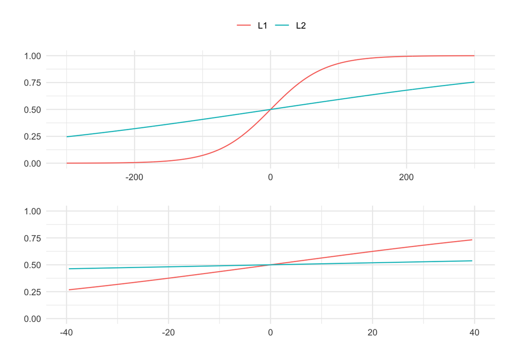

```
## c: 0.02546404 d: 0.00374196
```

```r
# Plot using the best-fitting estimates obtained so far
sigmoid_fig(
  c = 0.02546404,
  d = 0.00374196
)
```

# Appendix F

- **Figure F.1** Relationship between bids and valuations across N

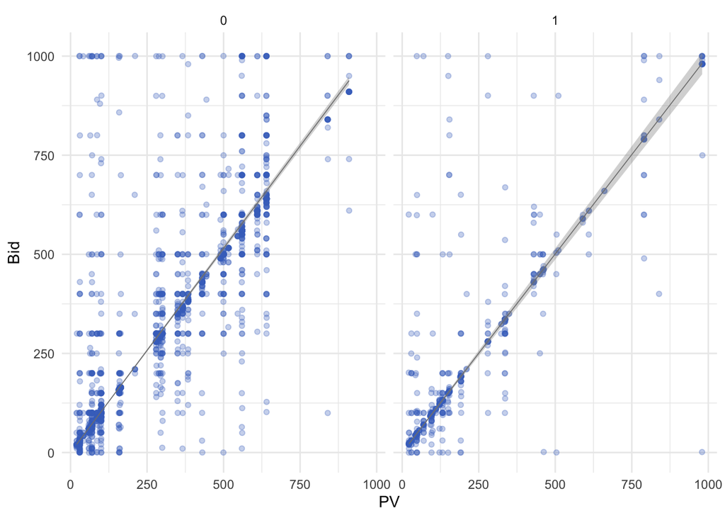

```r
tidy_data %>%
  plot_bid(g = "is_group4")
```

- **Figure F.2** Relationship between bids and valuations across δ

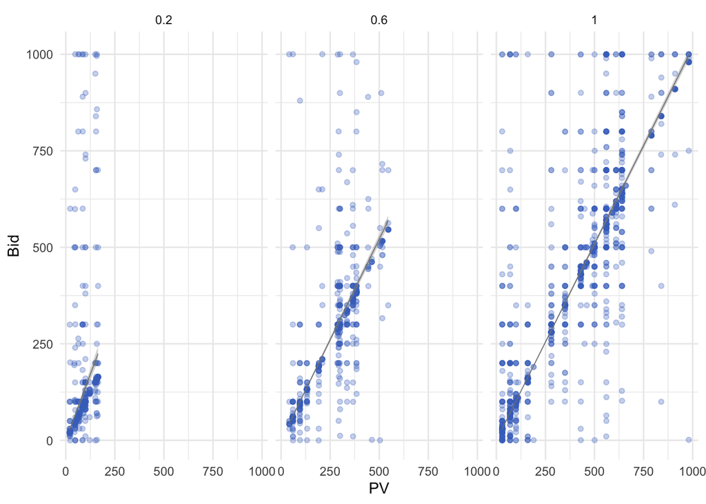

```r
tidy_data %>%
  plot_bid(g = "delta")
```